# The relationship between critical ambient water temperature, body mass and thermal strategy

Andrew L Jackson

## Setup

```r
# load the predictFishRMR package
library(predictFishRMR)

# for plotting and tibble manipulation
library(tidyverse)

# for extracting the coefficients of the brms regression model
# library(brms)
```

## Sensitivity of our estimate on K

In this example we explore how our estimate of critical ambient temperature, above which we predict a fish to be unable to maintain long term thermal equilibrium. We generate estimates over a range of body masses for both thermal strategies of mesothermy and ectothermy. We use the mean K as predicted according to Nakamura’s approach alongside a sensitivity whereby this value is assumed to vary by a factor of 2 in both directions (i.e. K is taken as both double and half its predicted value), thereby providing a 4-fold range.

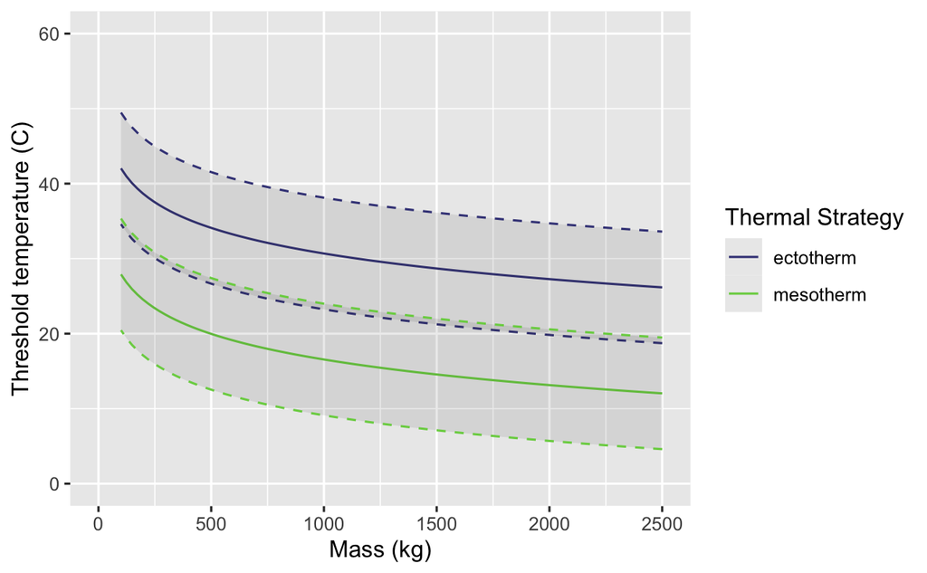

```r
# generate a sequence of mass for the x-axis of the plots
m_range <- seq(100, 2500, length.out = 100)

# load and retrieve the parameters for the RMR regression
# order of the parameters is:
# 1 = Intercept (gamma)
# 2 = alpha the coefficient of log10(mass)
# 3 = beta the coefficient of Body temperature
# 4 = the effect of mesothermy (psi)
data("fittedModelRMR")
pars <- fittedModelRMR

# calculate the mean predicted Ta_crit for the mass vector
Ta_crit_meso <- maxAmbientTemp(m_range, meso = TRUE,
                               pars, preK = 1,
                               kpars = c(0.00174, -0.6318))
Ta_crit_ecto <- maxAmbientTemp(m_range, meso = FALSE,
                               pars, preK = 1,
                               kpars = c(0.00174, -0.6318))

# calculate Ta_crit using 2*K in the calculations
Ta_crit_meso_high <- maxAmbientTemp(m_range, meso = TRUE,
                                    pars, preK = 2,
                                    kpars = c(0.00174, -0.6318))
Ta_crit_ecto_high <- maxAmbientTemp(m_range, meso = FALSE,
                                    pars, preK = 2,
                                    kpars = c(0.00174, -0.6318))

# calculate Ta_crit using K/2 in the calculations
Ta_crit_meso_low <- maxAmbientTemp(m_range, meso = TRUE,
                                   pars, preK = 0.5,
                                   kpars = c(0.00174, -0.6318))
Ta_crit_ecto_low <- maxAmbientTemp(m_range, meso = FALSE,
                                   pars, preK = 0.5,
                                   kpars = c(0.00174, -0.6318))

# assemble the data.frame (tibble) for plotting
dd_crit <- tibble(mass = rep(m_range, 2),
                      Ta_crit = c(Ta_crit_meso,   Ta_crit_ecto),
                      low = c(Ta_crit_meso_low,   Ta_crit_ecto_low),
                      high = c(Ta_crit_meso_high, Ta_crit_ecto_high),
                      'Thermal Strategy' = c(rep("mesotherm", length(m_range)),
                               rep("ectotherm", length(m_range))))


# plot the curves including the sensitivity as a ribbon plot
gg_crit <- ggplot(data = dd_crit,
                  mapping = aes(x = mass, y = Ta_crit,
                                color = `Thermal Strategy`)) +
  geom_path() +
  scale_color_viridis_d(option = "D", begin = 0.2, end = 0.8) +
  geom_ribbon(aes(ymin = low,
                  ymax = high),
              alpha = 0.1,
              linetype = 2,
              show.legend = FALSE) +
  ylab("Threshold temperature (C)") +
  xlab("Mass (kg)") +
  ylim(c(0,60)) +
  xlim(c(0, 2500))

# print to screen
print(gg_crit)

ggsave("compare_k_sensitivity.pdf",
       gg_crit + annotate("text", x = 100, y = 58, label  = "B"))
```

### Alternative estimates of K

The regression model that predicts cooling coefficient K can be created either including or excluding the two large planktivorous fish: whale sharks and basking sharks. The effect of this choice on critical water temperature is as follows:

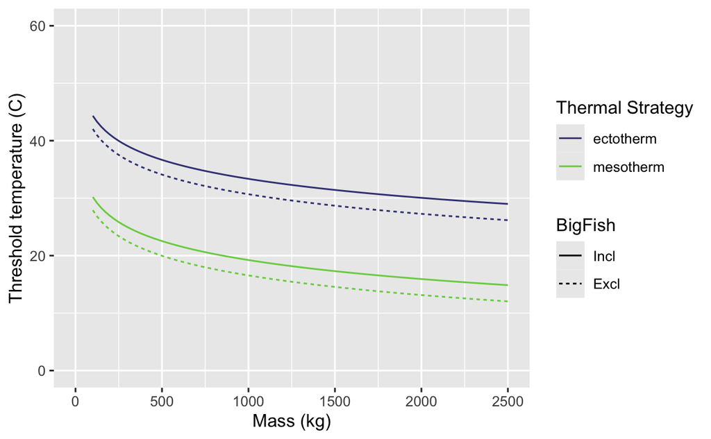

```r
# generate a sequence of mass for the x-axis of the plots
m_range <- seq(100, 2500, length.out = 100)

kk_incl <- kfun(m_range, kpars = c(0.00201, -0.6166))
kk_excl <- kfun(m_range, kpars = c(0.00174, -0.6318))

# dd_test <- tibble(mass = rep(m_range, 2),
#                   'Thermal Strategy' = c(rep("mesotherm", length(m_range)),
#                           rep("ectotherm", length(m_range))),
#                   K = c(kk_incl, kk_excl))
#
# gg_test <- ggplot(dd_test, mapping = aes(x = mass, y = K,
#                                 color = `Thermal Strategy`)) +
#   geom_line() +
#   scale_x_log10() +
#   scale_y_log10()
# print(gg_test)

# load and retrieve the parameters for the RMR regression
# order of the parameters is:
# 1 = Intercept (gamma)
# 2 = alpha the coefficient of log10(mass)
# 3 = beta the coefficient of Body temperature
# 4 = the effect of mesothermy (psi)
data("fittedModelRMR")
pars <- fittedModelRMR

# calculate Ta_crit regression that includes basking and whale sharks
Ta_crit_meso_incl <- maxAmbientTemp(m_range, meso = TRUE, pars,
                                    kpars = c(0.00201, -0.6166))
Ta_crit_ecto_incl <- maxAmbientTemp(m_range, meso = FALSE, pars,
                                    kpars = c(0.00201, -0.6166))

# calculate Ta_crit regression that excludes basking and whale sharks
Ta_crit_meso_excl <- maxAmbientTemp(m_range, meso = TRUE, pars,
                                    kpars = c(0.00174, -0.6318))
Ta_crit_ecto_excl <- maxAmbientTemp(m_range, meso = FALSE, pars,
                                    kpars = c(0.00174, -0.6318))

# assemble the data.frame (tibble) for plotting
dd_Kmodel <- tibble(mass = rep(m_range, 4),
                  Ta_crit = c(Ta_crit_meso_incl, Ta_crit_ecto_incl,
                              Ta_crit_meso_excl, Ta_crit_ecto_excl),
                  'Thermal Strategy' = rep(
                    c(rep("mesotherm", length(m_range)),
                      rep("ectotherm", length(m_range))),
                    2),
                  BigFish =
                    c(rep("Incl", length(m_range)), rep("Incl", length(m_range)),
                      rep("Excl", length(m_range)),rep("Excl", length(m_range)) )
) |>
  mutate(BigFish = factor(BigFish, levels = c("Incl", "Excl")))


# plot the curves including the sensitivity as a ribbon plot
gg_Kmodel <- ggplot(data = dd_Kmodel,
                  mapping = aes(x = mass, y = Ta_crit,
                                color = `Thermal Strategy`,
                                linetype = BigFish)) +
  geom_path() +
  scale_color_viridis_d(option = "D", begin = 0.2, end = 0.8) +
  ylab("Threshold temperature (C)") +
  xlab("Mass (kg)") +
  ylim(c(0,60)) +
  xlim(c(0, 2500))

# print to screen
print(gg_Kmodel)

ggsave("compare_k_regression.pdf",
       gg_Kmodel + annotate("text", x = 100, y = 58, label  = "A"))
```